# תרגול אחת עשרה - Neural Networks: Perceptron & Multilayered Perceptron

בתרגול זה נכיר מודל אחד של רשת נוירונים - מודל פרספטרון רב שכבתי. נראה תחילה דוגמה לרשת כזו המכילה 12 אינפוטים, שתי שכבות נסתרות עם חמישה נוירונים כל אחת ושכבת אאוטפוט עם שני נוירונים:

[figure not shown]

לפני שנבין מה הרשת עושה, נתמקד תחילה באבן היסוד שלה - הפרספטרון:

[figure not shown]

הפרספטרון הוא למעשה פונקציה המכילה פרמטרים. בהינתן אינפוט, הפרספטרון כופל את הפרמטרים באינפוטים, סוכם, מחיל פונקציה כלשהי על התוצאה ופולט מספר אחד ויחיד בתור פלט:

\begin{align} Z = w_0 + a_1 \cdot w_1 + a_2 \cdot w_2 = W \cdot A\\ output_0 = f(Z)\\ f(x) = \sigma (x) \\ \\ Z > 0 \rightarrow output_0 > 0.5 \\ Z < 0 \rightarrow output_0 < 0.5 \end{align}

מהמשוואות למעלה אנחנו מבינים שאת הסכימה ניתן לבטא ככפל מטריצה בווקטור.  
כאשר מחילים פונקציה מסוג סיגמואיד (כמו שמוצג באיור) הנוירון יצביע על הסתברות גדולה מחצי אם תוצאת הסכימה גדולה מ0, ועל הסתברות קטנה מחצי אם תוצאת הסכימה קטנה מאפס.  
נראה מוכר? זה בדיוק המשוואות של רגרסיה לוגיסטית.

## שאלה 1

א. נותונים דאטא בקובץ 11_data_1.csv. טענו את הקובץ ושרטטו את הנתונים.

```python
import pandas as pd
import matplotlib.pyplot as plt

data1 = pd.read_csv('11_data_1.csv')
data1.sample(5)
```

|  | x | y | class |
| --- | --- | --- | --- |
| 2 | -0.544500 | 0.409807 | 1 |
| 28 | 0.977021 | -0.810268 | 0 |
| 18 | -0.110027 | 1.076039 | 1 |
| 7 | -0.046748 | 0.322727 | 1 |
| 26 | -2.373224 | -1.213620 | 0 |

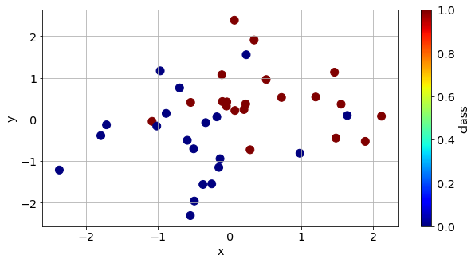

```python
params = {'legend.fontsize': 'x-large',
          'figure.figsize': (10, 5),
         'axes.labelsize': 'x-large',
         'axes.titlesize':'x-large',
         'xtick.labelsize':'x-large',
         'ytick.labelsize':'x-large',
         'axes.grid':True,
         'axes.grid.which':'both'
         }
plt.rcParams.update(params)

data1.plot.scatter(
    x='x',
    y='y',
    c='class',
    cmap='jet',
    sharex=False,
    s=100
)
```

ב. מצאו בעזרת מודל הפרספטרון מפריד לינארי להפרדה בין שתי המחלקות.

נכיר את הפרקטיקה מאחורי רשתות נוירונים. בעולם הזה קיימות שתי ספריות לפייתון: TensorFlow מבית גוגל ו PyTorch מבית פייסבוק.  
אנחנו נכיר את הספרייה PyTorch המייצגת איזון "טוב" בין נוחות ושקיפות של המודל.  
נבנה מודל פרספטרון אחד - רשת לינארית למעבר משני אינפוטים לאאוטפוט אחד ופונקצית סיגמואיד.

```python
import torch
import torch.nn as nn

model = nn.Sequential(
    nn.Linear(2,1),
    nn.Sigmoid()
)


mse_loss = nn.MSELoss()
optimizer = torch.optim.SGD(model.parameters(), lr=1)

model
```

```
Sequential(
  (0): Linear(in_features=2, out_features=1, bias=True)
  (1): Sigmoid()
)
```

למעלה מוצג המודל. נשים לב שאחרי שהגדרנו את המודל, הגדרנו מה תהיה השגיאה - שגיאת L2 רגילה - ואיך נבצע את הצעדים במורד הגרדיאנט - על ידי Stochastic Gradient Descent.  
כל שנותר הוא לאמן:

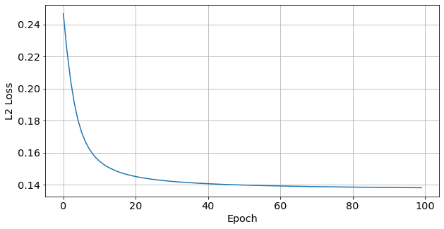

```python
losses = list()

model.train()

input = torch.Tensor(
    data1[['x','y']].values
)
target = torch.Tensor(
    data1['class'].values
)

for epoch in range(100):


    output = model(input)

    loss = mse_loss(output.view(-1), target)

    optimizer.zero_grad()
    loss.backward()
    optimizer.step()

    losses.append(loss.item())

plt.plot(losses)
plt.xlabel('Epoch')
plt.ylabel('L2 Loss')
```

מעבר אחד על כל הדאטא לרוב מוגדר בתור אפוק. לכל אפוק נבקש פרדיקציות מהמודל. נשווה את הפרדיקציות לליבלים ונמצא מה השגיאה. פייטורצ' יודעת לחשב עבורינו את הגרדיאנטים של המודל (backward) ולבצע צעד במורד הגרדיאנט (step).

ננסה להבין מה המודל מצא באמצעות הטבלה למטה.

```python
pd.concat(
    [
        data1['class'],
        pd.DataFrame(output.detach().numpy(), columns=["model output"])
    ],
    axis=1
).sample(5)
```

|  | class | model output |
| --- | --- | --- |
| 29 | 0 | 0.264552 |
| 20 | 0 | 0.505285 |
| 22 | 0 | 0.027209 |
| 15 | 1 | 0.953174 |
| 18 | 1 | 0.785797 |

נשים לב שלכל דגימה יש הסתברות. נאמר שאם ההסבתרות גדולה מ0.5 הדגימה שייכת למחלקה 1, אחרת - 0.

לבסוף נמצא את המפריד הלינארי.

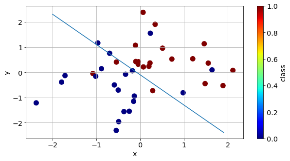

```python
import numpy as np
def return_line(weight,b):
    ax, ay = model._modules['0'].weight.detach().squeeze().numpy()
    b = b.item()
    xs = np.arange(-2, 2, 0.1)

    ys = (-1 * ax * xs - b) / ay

    return xs, ys

data1.plot.scatter(
    x='x',
    y='y',
    c='class',
    cmap='jet',
    sharex=False,
    s=100
)

xs,ys = return_line(
    model._modules['0'].weight,
    model._modules['0'].bias
)
plt.plot(xs,ys)
```

## שאלה 2

א. נתונים דאטא בקובץ 11_data2.csv. באופן דומה לשאלה 1 - שרטטו את הנתונים ומצאו מפריד לינארי לסיווג בין המחלקות.

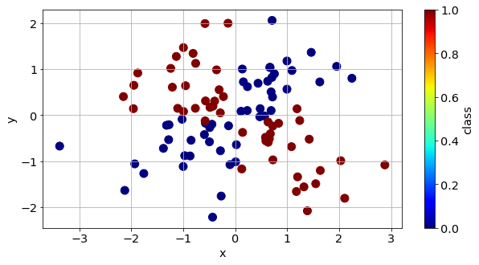

```python
data2 = pd.read_csv('11_data_2.csv')
data2.plot.scatter(
    x='x',
    y='y',
    c='class',
    cmap='jet',
    sharex=False,
    s=100
)
```

נשים לב לפיזור של המחלקות במישור. הפיזור הולך לפי החיוביות או השליליות של הצירים, רק עם רעש. פיזור כזה נוצר על ידי פונקציית XOR עם רעש על הצירים והבעיה ידועה בתור בעיית ה XOR. האם ניתן למצוא מפריד לינארי? לא. מודל פרפסטרון יכשל במקרה כזה.  
נעשה טריק. נשכפל את הדאטא, נכפיל את הנקודות במטריצת מעבר כלשהי ונוסיף היסט כלשהו, ולבסוף נפעיל טנגנס היפרבולי. כרגע נתעלם מבעיית המציאה של המטריצה וההיסט.

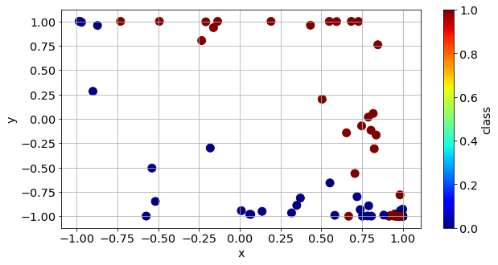

```python
data2_2 = data2.copy()

transform = np.array(
    [[-1.6764, -0.6350],
     [ 3.9198, -1.5375]]
)

bias = np.array([[ 1.8471, -3.3447]])

data2_2 = data2.copy()

data2_2[['x','y']] = np.tanh(
    data2[['x','y']].dot(transform.T) + bias#
)

data2_2.plot.scatter(
    x=0,
    y=1,
    c='class',
    cmap='jet',
    sharex=False,
    s=100
)
```

נשים לב לפיזור מעל - הוא ניתן להפרדה בצורה לינארית (אמנם אם שגיאה כי קיים רעש בדאטא).

חדי העין ישימו לב שהכפלה במטריצה, הוספת ביאס והפעלת פונקציה שקולה להוספת שכבה של פרספטרונים. מכאן נובע הצורך למודל פרספטרון רב שכבתי.

[figure not shown]

על ידי הוספת שכבה אנחנו מסוגלים להעביראת הנקודות למרחב ווקטורי בו הן ניתנות להפרדה לינארית והמפריד ישמש כמו ברגרסיה לוגיסטית רגילה.  
לסיכום נראה שכל שכבה לינארית ניתנת לכתיבה ככפל מטריצה והוספת ביאס:

\begin{align} Z = W \cdot x + b \\ y = f(Z) \end{align}

## שאלה 3

בשנת 1995 קבוצת מחקר מאוניברסיטת וויסקונסין שחררה מידע על אודות 569 דגימות מנגעים ברקמת השד - חלקם ממאירים וחלקים שפירים. החוקרים הפיקו נתונים כמותיים אודות גרעיני התאים שנצפו בדגימה תחת המיקרוסקופ ומטרתם הייתה לפתח כלי אוטומטי לאיבחון ממאירות של הנגע.  
המידע זמין להורדה בחבילה sklearn.

א. טענו את הקובץ לאובייקט מסוג DataFrame. הכינו את הדאטא לעבודה עם רשתות נוירונים.

על מנת להכין את הדאטא בצורה טובה ננרמל כך שיתקבלו מספרים קטנים ביחס לערכים שפונקציות לא לינאריות כמו סיגמואיד וטנגנס היפרבולי יכולות לקבל לפני שהן מגיעות לרוויה:

```python
from sklearn import datasets
dataset = datasets.load_breast_cancer()

data3 = pd.DataFrame(

    dataset['data'],
    columns=dataset['feature_names']

)

data3['diagnosis'] = dataset['target']

df_diagnosis = data3['diagnosis']

data3 = (data3 - data3.mean()) / (data3.std() + 1e-10)

data3['diagnosis'] = df_diagnosis
data3.sample(5)
```

|  | mean radius | mean texture | mean perimeter | mean area | mean smoothness | mean compactness | mean concavity | mean concave points | mean symmetry | mean fractal dimension | ... | worst texture | worst perimeter | worst area | worst smoothness | worst compactness | worst concavity | worst concave points | worst symmetry | worst fractal dimension | diagnosis |
| --- | --- | --- | --- | --- | --- | --- | --- | --- | --- | --- | --- | --- | --- | --- | --- | --- | --- | --- | --- | --- | --- |
| 494 | -0.274483 | 0.290709 | -0.325488 | -0.330163 | -1.636097 | -0.976866 | -0.888102 | -0.937023 | -0.359735 | -0.554874 | ... | 0.452760 | -0.356259 | -0.407974 | -0.900850 | -0.569894 | -0.935694 | -1.105334 | -0.345506 | -0.534615 | 1 |
| 327 | -0.595137 | -0.316121 | -0.653486 | -0.593580 | -1.388659 | -1.238734 | -1.094500 | -1.116597 | -1.567134 | -0.297097 | ... | -0.557611 | -0.729743 | -0.627345 | -1.360722 | -1.146365 | -1.267621 | -1.318167 | -1.179547 | -0.751654 | 1 |
| 278 | -0.152464 | -0.337046 | -0.235773 | -0.234685 | -1.200237 | -1.208439 | -0.863390 | -0.941662 | -0.870417 | -1.076093 | ... | 0.068786 | -0.248529 | -0.248496 | -1.198672 | -1.131620 | -0.796592 | -0.954724 | -0.914464 | -1.180195 | 1 |
| 500 | 0.258994 | -0.592799 | 0.278241 | 0.098066 | 0.175604 | 0.607032 | -0.145376 | 0.322163 | -0.523883 | 0.834573 | ... | -0.853727 | 0.072577 | -0.041596 | -0.826394 | -0.233036 | -0.415045 | -0.194824 | -1.169849 | 0.085497 | 1 |
| 315 | -0.464605 | -0.567223 | -0.525908 | -0.492419 | -0.799927 | -1.249717 | -1.057784 | -1.095181 | -2.176306 | -0.859391 | ... | -0.970871 | -0.677961 | -0.590812 | -0.962166 | -1.301256 | -1.211788 | -1.319993 | -1.590102 | -1.229472 | 1 |

5 rows × 31 columns

ב. חלקו את הדאטא לקבוצת אימון ולקבוצת וולידציה ואמנו מודל MLP לבחירתכם.

```python
from sklearn.model_selection import train_test_split

data3_train, data3_val = train_test_split(
    data3,
    train_size = 0.8,
    stratify = data3['diagnosis']
)
```

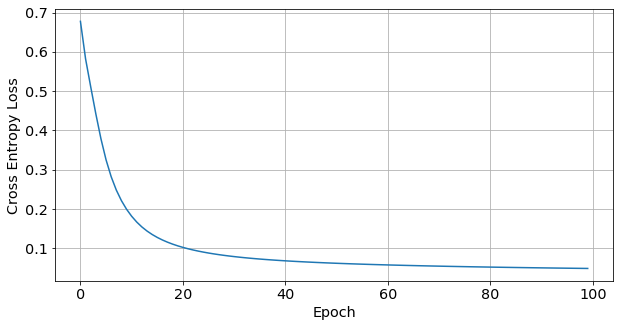

```python
model = nn.Sequential(
    nn.Linear(30,10),
    nn.Sigmoid(),
    nn.Linear(10,2)
)

model.train()

ce_loss = nn.CrossEntropyLoss()
optimizer = torch.optim.SGD(model.parameters(), lr=1)

losses = list()


for epoch in range(100):
    input = torch.Tensor(
        data3_train.drop('diagnosis', axis='columns').values
    )
    target = torch.Tensor(
        data3_train['diagnosis'].values
    )

    output = model(input)

    loss = ce_loss(output, target.long())

    optimizer.zero_grad()
    loss.backward()
    optimizer.step()

    losses.append(loss.item())


plt.plot(losses)
plt.xlabel('Epoch')
plt.ylabel('Cross Entropy Loss')
```

ניבחן על קבוצת הוולידציה:

```python
model.eval()

input = torch.Tensor(
    data3_val.drop('diagnosis', axis='columns').values
)

output = model(input).argmax(dim=1).detach().numpy()


from sklearn.metrics import accuracy_score
accuracy_score(data3_val['diagnosis'].values, output)
```

```
0.9736842105263158
```

לבסוף נרצה לראות את המודל שלנו:

[figure not shown]

זה מודל בסיסי בעולם של רשתות נוירונים. המודל הבסיסי הצליח להגיע לקלסיפיקציה מאוד גבוהה. זה זמן טוב לחשוב על יתרון ועל חיסרון של המודל. יתרון שלו הוא שהמודל יכול ללמוד ייצוג מאוד מורכב של הדאטא - הוא ימצא איך להעביר אותו למישור בו המחלקות ניתנות להפרדה בעצמו. חיסרון אחד (מיני רבים) הוא מספר הפרמטרים. במודל הפשוט שלנו יש למעלה מ300 פרמטרים - דבר שמצריך כמות דאטא מאוד גדולה לאימון.